# Rearranjo de Dados e Medidas Resumo com `dplyr` - Parte 4

## Introdução

Nesta aula, vamos explorar como realizar operações de rearranjo em tabelas, calcular medidas resumo, fazer agregações, concatenar tabelas, e realizar junções utilizando o pacote `dplyr`. Usaremos as tabelas de `produtos`, `vendas`, e `vendedores` que criamos anteriormente.

## Rearranjo de Dados

Rearranjo envolve modificar a disposição dos registros em uma tabela. As operações mais comuns são empilhar e esparramar variáveis.

## Tabelas Utilizadas

Primeiro, vamos carregar as tabelas criadas na aula anterior.

```r
library(tidyverse)

# Tabela de Produtos
produtos <- tibble(
  produto_id = c(101, 102, 103, 104, 105),
  nome_produto = c("Café", "Açúcar", "Leite", "Arroz", "Feijão"),
  categoria = c("Alimentos", "Alimentos", "Laticínios", "Alimentos", "Alimentos"),
  preco = c(8.50, 2.80, 3.20, 10.00, 7.50)
)

# Tabela de Vendas
vendas <- tibble(
  venda_id = c(1001, 1002, 1003, 1004, 1005),
  produto_id = c(101, 102, 103, 104, 105),
  vendedor_id = c(1, 2, 1, 3, 2),
  quantidade = c(10, 5, 8, 3, 4),
  data_venda = as.Date(c("2024-07-01", "2024-07-02", "2024-07-03", "2024-07-04", "2024-07-05"))
)

# Tabela de Vendedores
vendedores <- tibble(
  vendedor_id = c(1, 2, 3),
  nome_vendedor = c("Alice", "Bruno", "Carla"),
  regiao = c("Norte", "Sul", "Leste")
)

# Visualizando as tabelas
produtos
```

| produto_id | nome_produto | categoria | preco |
| --- | --- | --- | --- |
| 101 | Café | Alimentos | 8.5 |
| 102 | Açúcar | Alimentos | 2.8 |
| 103 | Leite | Laticínios | 3.2 |
| 104 | Arroz | Alimentos | 10.0 |
| 105 | Feijão | Alimentos | 7.5 |

```r
vendas
```

| venda_id | produto_id | vendedor_id | quantidade | data_venda |
| --- | --- | --- | --- | --- |
| 1001 | 101 | 1 | 10 | 2024-07-01 |
| 1002 | 102 | 2 | 5 | 2024-07-02 |
| 1003 | 103 | 1 | 8 | 2024-07-03 |
| 1004 | 104 | 3 | 3 | 2024-07-04 |
| 1005 | 105 | 2 | 4 | 2024-07-05 |

```r
vendedores
```

| vendedor_id | nome_vendedor | regiao |
| --- | --- | --- |
| 1 | Alice | Norte |
| 2 | Bruno | Sul |
| 3 | Carla | Leste |

### Empilhar Variáveis (`pivot_longer`)

Empilhar dados significa transformar colunas em linhas. Isso é útil quando queremos compactar variáveis em uma única coluna. Por exemplo, vamos empilhar as variáveis de `vendas` (quantidade, preco) em uma tabela longa:

| venda_id | produto_id | vendedor_id | data_venda | nome_produto | categoria | tipo_dado | valor |
| --- | --- | --- | --- | --- | --- | --- | --- |
| 1001 | 101 | 1 | 2024-07-01 | Café | Alimentos | quantidade | 10.0 |
| 1001 | 101 | 1 | 2024-07-01 | Café | Alimentos | preco | 8.5 |
| 1002 | 102 | 2 | 2024-07-02 | Açúcar | Alimentos | quantidade | 5.0 |
| 1002 | 102 | 2 | 2024-07-02 | Açúcar | Alimentos | preco | 2.8 |
| 1003 | 103 | 1 | 2024-07-03 | Leite | Laticínios | quantidade | 8.0 |
| 1003 | 103 | 1 | 2024-07-03 | Leite | Laticínios | preco | 3.2 |

### Esparramar Variáveis (`pivot_wider`)

Esparramar é o oposto de empilhar. Transforma linhas em colunas. Vamos pegar a tabela empilhada e esparramar de volta para o formato original:

| venda_id | produto_id | vendedor_id | data_venda | nome_produto | categoria | quantidade | preco |
| --- | --- | --- | --- | --- | --- | --- | --- |
| 1001 | 101 | 1 | 2024-07-01 | Café | Alimentos | 10 | 8.5 |
| 1002 | 102 | 2 | 2024-07-02 | Açúcar | Alimentos | 5 | 2.8 |
| 1003 | 103 | 1 | 2024-07-03 | Leite | Laticínios | 8 | 3.2 |
| 1004 | 104 | 3 | 2024-07-04 | Arroz | Alimentos | 3 | 10.0 |
| 1005 | 105 | 2 | 2024-07-05 | Feijão | Alimentos | 4 | 7.5 |

## Medidas Resumo

Medidas resumo são essenciais para analisar e entender os dados. Podem ser medidas de posição, como média e mediana, ou de dispersão, como desvio padrão.

### Medidas Resumo Simples

Vamos calcular algumas medidas resumo na tabela de `vendas`, como a soma, média e desvio padrão do preço:

| soma_preco | media_preco | desvio_preco |
| --- | --- | --- |
| 32 | 6.4 | 3.231873 |

### Estatísticas por Grupos

Podemos calcular estatísticas para grupos específicos. Por exemplo, calcular a média de `quantidade` por `vendedor_id`:

| vendedor_id | media_quantidade |
| --- | --- |
| 1 | 9.0 |
| 2 | 4.5 |
| 3 | 3.0 |

### Medidas de Posição e Dispersão

Podemos calcular medidas de posição e dispersão para mais de uma variável. Por exemplo, calcular a média e desvio padrão de `quantidade` e `preco`:

| quantidade_media | preco_media | quantidade_desvio | preco_desvio |
| --- | --- | --- | --- |
| 6 | 6.4 | 2.915476 | 3.231873 |

### Coeficiente de Variação

O coeficiente de variação (CV) é uma medida de dispersão relativa. Vamos calcular o CV para o preço:

```r
CV <- function(x) { 100 * sd(x, na.rm = TRUE) / mean(x, na.rm = TRUE) }
vendas_completa %>%
  summarise(cv_preco = CV(preco))
```

| cv_preco |
| --- |
| 50.49801 |

## Agregação

Agregação envolve a aplicação de funções de resumo em grupos de dados. É uma forma poderosa de entender como diferentes grupos se comportam em relação às variáveis de interesse.

### Agregação por Grupos

Vamos calcular a soma e média de `quantidade` e `preco` para cada `vendedor_id`:

```r
vendas_completa %>%
  group_by(vendedor_id) %>%
  summarise_at(vars(quantidade, preco), list(soma = sum, media = mean), na.rm = TRUE)
```

| vendedor_id | quantidade_soma | preco_soma | quantidade_media | preco_media |
| --- | --- | --- | --- | --- |
| 1 | 18 | 11.7 | 9.0 | 5.85 |
| 2 | 9 | 10.3 | 4.5 | 5.15 |
| 3 | 3 | 10.0 | 3.0 | 10.00 |

## Concatenação

Concatenação permite unir tabelas por linhas ou colunas. É útil quando temos tabelas separadas que queremos combinar.

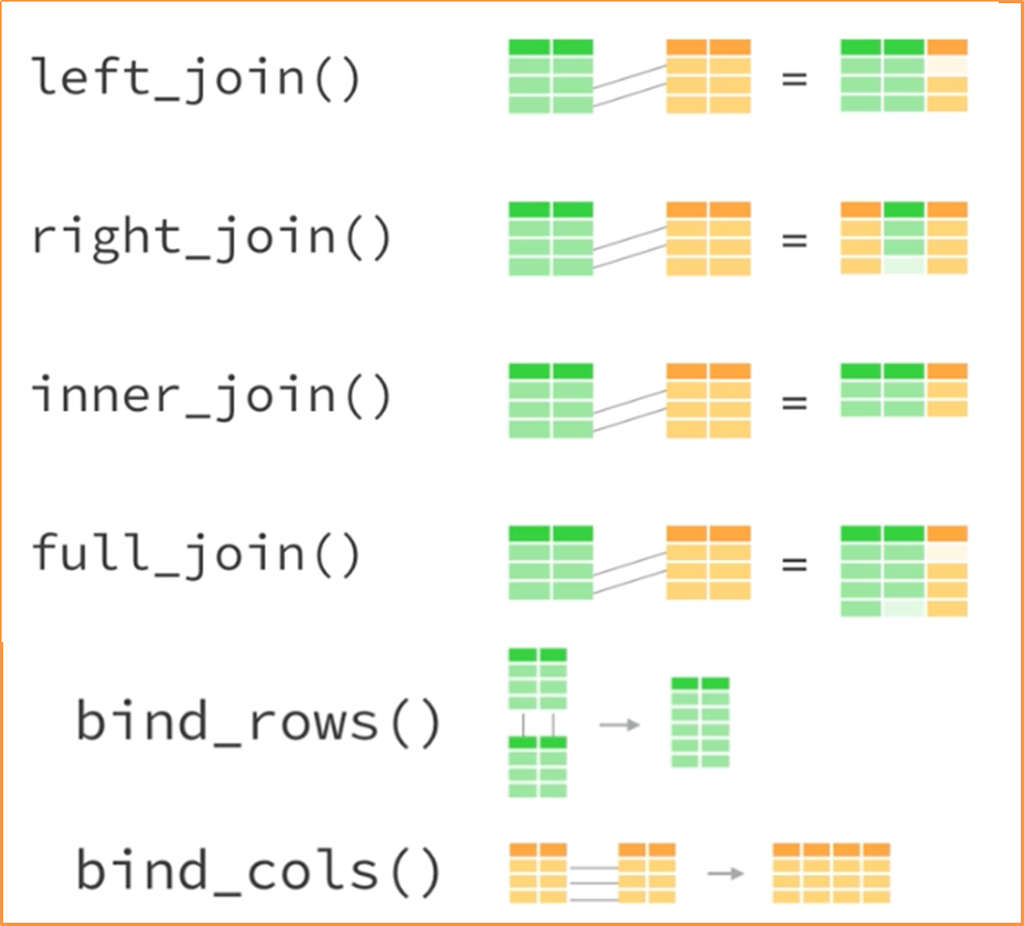

### Concatenação por Linhas (`bind_rows`)

Vamos concatenar duas partes de `vendas`:

| venda_id | produto_id | vendedor_id | quantidade | data_venda |
| --- | --- | --- | --- | --- |
| 1004 | 104 | 3 | 3 | 2024-07-04 |
| 1005 | 105 | 2 | 4 | 2024-07-05 |
| NA | NA | NA | NA |  |

### Concatenação por Colunas (`bind_cols`)

Vamos adicionar novas colunas à tabela `produtos`:

| produto_id | nome_produto | categoria | preco | desconto | estoque |
| --- | --- | --- | --- | --- | --- |
| 101 | Café | Alimentos | 8.5 | 0.10 | 100 |
| 102 | Açúcar | Alimentos | 2.8 | 0.20 | 150 |
| 103 | Leite | Laticínios | 3.2 | 0.15 | 120 |
| 104 | Arroz | Alimentos | 10.0 | 0.30 | 99 |
| 105 | Feijão | Alimentos | 7.5 | 0.10 | 80 |

## Junções

Junções combinam dados de diferentes tabelas com base em uma chave comum. Isso é útil para reunir informações espalhadas em várias tabelas.

### Junção por Interseção (`inner_join`)

Vamos combinar as tabelas `vendas` e `vendedores` com base em `vendedor_id`:

| venda_id | produto_id | vendedor_id | quantidade | data_venda | nome_vendedor | regiao |
| --- | --- | --- | --- | --- | --- | --- |
| 1001 | 101 | 1 | 10 | 2024-07-01 | Alice | Norte |
| 1002 | 102 | 2 | 5 | 2024-07-02 | Bruno | Sul |
| 1003 | 103 | 1 | 8 | 2024-07-03 | Alice | Norte |
| 1004 | 104 | 3 | 3 | 2024-07-04 | Carla | Leste |
| 1005 | 105 | 2 | 4 | 2024-07-05 | Bruno | Sul |

### Junção por União (`full_join`)

Combina todos os registros de ambas as tabelas:

| venda_id | produto_id | vendedor_id | quantidade | data_venda | nome_produto | categoria | preco |
| --- | --- | --- | --- | --- | --- | --- | --- |
| 1001 | 101 | 1 | 10 | 2024-07-01 | Café | Alimentos | 8.5 |
| 1002 | 102 | 2 | 5 | 2024-07-02 | Açúcar | Alimentos | 2.8 |
| 1003 | 103 | 1 | 8 | 2024-07-03 | Leite | Laticínios | 3.2 |
| 1004 | 104 | 3 | 3 | 2024-07-04 | Arroz | Alimentos | 10.0 |
| 1005 | 105 | 2 | 4 | 2024-07-05 | Feijão | Alimentos | 7.5 |

### Junção à Esquerda (`left_join`)

Retorna todos os registros da tabela da esquerda e os correspondentes da tabela da direita:

| venda_id | produto_id | vendedor_id | quantidade | data_venda | nome_produto | categoria | preco |
| --- | --- | --- | --- | --- | --- | --- | --- |
| 1001 | 101 | 1 | 10 | 2024-07-01 | Café | Alimentos | 8.5 |
| 1002 | 102 | 2 | 5 | 2024-07-02 | Açúcar | Alimentos | 2.8 |
| 1003 | 103 | 1 | 8 | 2024-07-03 | Leite | Laticínios | 3.2 |
| 1004 | 104 | 3 | 3 | 2024-07-04 | Arroz | Alimentos | 10.0 |
| 1005 | 105 | 2 | 4 | 2024-07-05 | Feijão | Alimentos | 7.5 |

### Junção à Direita (`right_join`)

Retorna todos os registros da tabela da direita e os correspondentes da tabela da esquerda:

| venda_id | produto_id | vendedor_id | quantidade | data_venda | nome_produto | categoria | preco |
| --- | --- | --- | --- | --- | --- | --- | --- |
| 1001 | 101 | 1 | 10 | 2024-07-01 | Café | Alimentos | 8.5 |
| 1002 | 102 | 2 | 5 | 2024-07-02 | Açúcar | Alimentos | 2.8 |
| 1003 | 103 | 1 | 8 | 2024-07-03 | Leite | Laticínios | 3.2 |
| 1004 | 104 | 3 | 3 | 2024-07-04 | Arroz | Alimentos | 10.0 |
| 1005 | 105 | 2 | 4 | 2024-07-05 | Feijão | Alimentos | 7.5 |

### Junção Exclusiva (`anti_join`)

Retorna os registros da primeira tabela que não têm correspondência na segunda:

| venda_id | produto_id | vendedor_id | quantidade | data_venda |
| --- | --- | --- | --- | --- |

## Conclusão

Neste notebook, aprendemos como realizar operações de rearranjo, calcular medidas resumo, fazer agregações, concatenar tabelas e realizar junções utilizando o `dplyr`. Estas operações são fundamentais para a análise e manipulação de dados em R, permitindo uma visão mais profunda e detalhada dos dados.